# Binary Classification

```python
import os
import warnings
import logging

# configure logging
logging.basicConfig(
    level=logging.INFO, format="%(asctime)s [%(levelname)s] %(message)s", datefmt="%H:%M:%S",
)
logger = logging.getLogger(__name__)

# get warning filter policy from the environment variables
# set to "ignore" for rendering the HTMLs, or to "once" otherwise
WARNING_FILTER_POLICY = os.getenv("WARNING_FILTER_POLICY", "once")
logger.info(f"{WARNING_FILTER_POLICY = }")
warnings.filterwarnings(WARNING_FILTER_POLICY)
```

```
21:11:31 [INFO] WARNING_FILTER_POLICY = 'ignore'
```

```python
import numpy as np
import pandas as pd
import seaborn as sns
import shap

from sklearn.preprocessing import StandardScaler
from sklearn.linear_model import LogisticRegression
from sklearn.model_selection import train_test_split, RepeatedStratifiedKFold, GridSearchCV
from statsmodels.stats.outliers_influence import variance_inflation_factor
from xgboost import XGBClassifier

pd.set_option("display.max_columns", None)
pd.options.display.float_format = "{:,.2f}".format
```

```python
from utils.constants import RANDOM_SEED
from utils.common import (
    get_data_folder_path,
    set_plotting_config,
    plot_boxplot_by_class,
    plot_correlation_matrix,
)
from utils.evals import (
    describe_input_features,
    plot_confusion_matrix,
    plot_target_rate,
    compute_binary_classification_metrics,
    build_coefficients_table,
    plot_coefficients_values,
    plot_coefficients_significance,
    plot_eval_metrics_xgb,
    plot_gain_metric_xgb,
    plot_shap_importance,
    plot_shap_beeswarm,
    build_ks_table,
    beautify_ks_table,
    plot_ks_table,
    plot_roc_curve,
)
from utils.feature_selection import run_feature_selection_steps
```

```python
# plots configuration
sns.set_style("darkgrid")
sns.set_palette("colorblind")
set_plotting_config()
%matplotlib inline
```

## 1. Load Data

In this notebook, we will use the **Fetal Health Dataset**. This dataset comprises 2126 records of features from Cardiotocogram exams, classified by experts into Normal, Suspect, and Pathological to assess fetal health and help reduce child and maternal mortality.

Sources:

1. Kaggle: https://www.kaggle.com/datasets/andrewmvd/fetal-health-classification
2. Original article: https://www.ncbi.nlm.nih.gov/pmc/articles/PMC68223152

```python
data_path = get_data_folder_path()

df_input = pd.read_csv(os.path.join(data_path, "fetal_health.csv"))
df_input.columns = [col.replace(" ", "_") for col in df_input.columns]
```

## 2. Process Data

### Target column

Fetal health (target column) can have the following values:

- 1: Normal
- 2: Suspect
- 3: Pathological

For this notebook, we will consider the Normal/not Normal distinction for binary classification

```python
target_col = "is_normal"
target_classes_dict = {
    0: "Not Normal",
    1: "Normal"
}
test_size = 0.20
```

```python
# create a new binary target column from the original multi-class target column
df_input[target_col] = (df_input["fetal_health"] == 1).astype(np.int8)
df_input.drop(columns=["fetal_health"], inplace=True)
```

### Train test split

```python
df_input_train, df_input_test = train_test_split(
    df_input,
    test_size=test_size,
    stratify=df_input[target_col],
    random_state=RANDOM_SEED,
)
```

```python
pd.concat([
    pd.Series(target_classes_dict, name="label"),
    df_input_train[target_col].value_counts(dropna=False, normalize=False).rename("train_target_count"),
    df_input_train[target_col].value_counts(dropna=False, normalize=True).rename("train_target_pct"),
    df_input_test[target_col].value_counts(dropna=False, normalize=False).rename("test_target_count"),
    df_input_test[target_col].value_counts(dropna=False, normalize=True).rename("test_target_pct"),
], axis=1)
```

|  | label | train_target_count | train_target_pct | test_target_count | test_target_pct |
| --- | --- | --- | --- | --- | --- |
| 0 | Not Normal | 377 | 0.22 | 94 | 0.22 |
| 1 | Normal | 1323 | 0.78 | 332 | 0.78 |

```python
describe_input_features(df_input, df_input_train, df_input_test)
```

|  | data_type | count | null_count | min | 25% | 50% | 75% | max | std | mean | mean_train | mean_test | train_test_pct_diff |
| --- | --- | --- | --- | --- | --- | --- | --- | --- | --- | --- | --- | --- | --- |
| baseline_value | numeric | 2126 | 0 | 106.00 | 126.00 | 133.00 | 140.00 | 160.00 | 9.84 | 133.30 | 133.23 | 133.60 | 0.00 |
| accelerations | numeric | 2126 | 0 | 0.00 | 0.00 | 0.00 | 0.01 | 0.02 | 0.00 | 0.00 | 0.00 | 0.00 | -0.01 |
| fetal_movement | numeric | 2126 | 0 | 0.00 | 0.00 | 0.00 | 0.00 | 0.48 | 0.05 | 0.01 | 0.01 | 0.01 | 0.11 |
| uterine_contractions | numeric | 2126 | 0 | 0.00 | 0.00 | 0.00 | 0.01 | 0.01 | 0.00 | 0.00 | 0.00 | 0.00 | 0.01 |
| light_decelerations | numeric | 2126 | 0 | 0.00 | 0.00 | 0.00 | 0.00 | 0.01 | 0.00 | 0.00 | 0.00 | 0.00 | -0.05 |
| severe_decelerations | numeric | 2126 | 0 | 0.00 | 0.00 | 0.00 | 0.00 | 0.00 | 0.00 | 0.00 | 0.00 | 0.00 | 1.99 |
| prolongued_decelerations | numeric | 2126 | 0 | 0.00 | 0.00 | 0.00 | 0.00 | 0.01 | 0.00 | 0.00 | 0.00 | 0.00 | 0.03 |
| abnormal_short_term_variability | numeric | 2126 | 0 | 12.00 | 32.00 | 49.00 | 61.00 | 87.00 | 17.19 | 46.99 | 47.06 | 46.70 | -0.01 |
| mean_value_of_short_term_variability | numeric | 2126 | 0 | 0.20 | 0.70 | 1.20 | 1.70 | 7.00 | 0.88 | 1.33 | 1.34 | 1.30 | -0.03 |
| percentage_of_time_with_abnormal_long_term_variability | numeric | 2126 | 0 | 0.00 | 0.00 | 0.00 | 11.00 | 91.00 | 18.40 | 9.85 | 9.72 | 10.34 | 0.06 |
| mean_value_of_long_term_variability | numeric | 2126 | 0 | 0.00 | 4.60 | 7.40 | 10.80 | 50.70 | 5.63 | 8.19 | 8.31 | 7.71 | -0.07 |
| histogram_width | numeric | 2126 | 0 | 3.00 | 37.00 | 67.50 | 100.00 | 180.00 | 38.96 | 70.45 | 71.20 | 67.46 | -0.05 |
| histogram_min | numeric | 2126 | 0 | 50.00 | 67.00 | 93.00 | 120.00 | 159.00 | 29.56 | 93.58 | 92.97 | 96.02 | 0.03 |
| histogram_max | numeric | 2126 | 0 | 122.00 | 152.00 | 162.00 | 174.00 | 238.00 | 17.94 | 164.03 | 164.16 | 163.48 | -0.00 |
| histogram_number_of_peaks | numeric | 2126 | 0 | 0.00 | 2.00 | 3.00 | 6.00 | 18.00 | 2.95 | 4.07 | 4.11 | 3.90 | -0.05 |
| histogram_number_of_zeroes | numeric | 2126 | 0 | 0.00 | 0.00 | 0.00 | 0.00 | 10.00 | 0.71 | 0.32 | 0.33 | 0.31 | -0.04 |
| histogram_mode | numeric | 2126 | 0 | 60.00 | 129.00 | 139.00 | 148.00 | 187.00 | 16.38 | 137.45 | 137.50 | 137.25 | -0.00 |
| histogram_mean | numeric | 2126 | 0 | 73.00 | 125.00 | 136.00 | 145.00 | 182.00 | 15.59 | 134.61 | 134.61 | 134.61 | -0.00 |
| histogram_median | numeric | 2126 | 0 | 77.00 | 129.00 | 139.00 | 148.00 | 186.00 | 14.47 | 138.09 | 138.05 | 138.24 | 0.00 |
| histogram_variance | numeric | 2126 | 0 | 0.00 | 2.00 | 7.00 | 24.00 | 269.00 | 28.98 | 18.81 | 19.45 | 16.24 | -0.16 |
| histogram_tendency | numeric | 2126 | 0 | -1.00 | 0.00 | 0.00 | 1.00 | 1.00 | 0.61 | 0.32 | 0.32 | 0.30 | -0.07 |
| is_normal | numeric | 2126 | 0 | 0.00 | 1.00 | 1.00 | 1.00 | 1.00 | 0.42 | 0.78 | 0.78 | 0.78 | 0.00 |

### Scaling (Standardization)

```python
# Standardize training and test data
stdscaler = StandardScaler()

# training data
y_train = df_input_train[target_col]
X_train_all = (
    pd.DataFrame(
        # fit scaler on training data (and then transform training data)
        data=stdscaler.fit_transform(df_input_train),
        columns=df_input_train.columns,
        index=df_input_train.index
    )
    # remove target from the model input features table
    .drop(columns=[target_col])
)

# test data
y_test = df_input_test[target_col]
X_test_all = (
    pd.DataFrame(
        # use scaler fitted on training data to transform test data
        data=stdscaler.transform(df_input_test),
        columns=df_input_test.columns,
        index=df_input_test.index
    )
    # remove target from the model input features table
    .drop(columns=[target_col])
)
```

## 3. Exploratory Data Analysis (EDA)

### Boxplots by Target Class

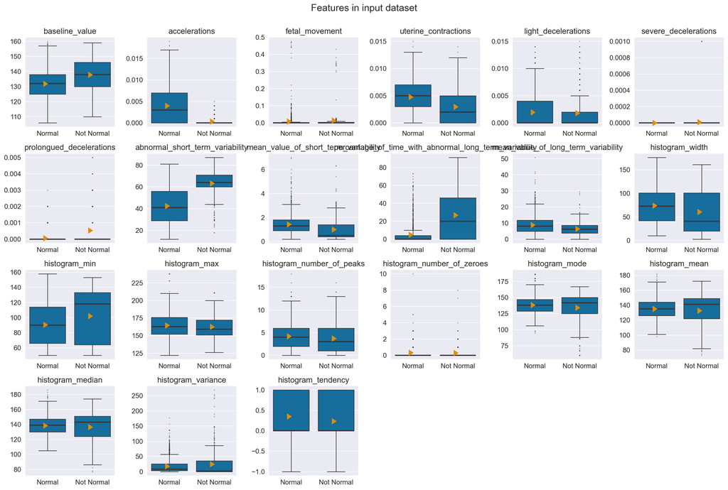

```python
display(
    plot_boxplot_by_class(
        df_input=df_input_train,  # use only training data to avoid bias in test results
        class_col=target_col,
        class_mapping=target_classes_dict,
        plots_per_line=6,
        title="Features in input dataset",
    )
)
```

### Pearson's Correlation

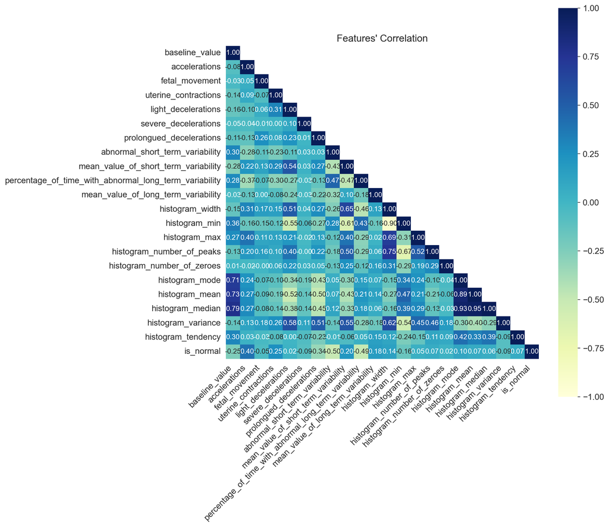

```python
display(
    plot_correlation_matrix(
        # use only training data to avoid bias in test results
        df=df_input_train, method="pearson", fig_height=10
    )
)
```

## 4. Feature Selection

```python
fs_steps = {
    "manual": {
        "cols_to_exclude": [
            "severe_decelerations",
        ]
    },
    "null_variance": None,
    "correlation": {"threshold": 0.8},
    "vif": {"threshold": 2},
    "l1_regularization": {
        "problem_type": "classification",
        "train_test_split_params": {"test_size": test_size},
        "logspace_search": {"start": -5, "stop": 1, "num": 20, "base": 10},
        # tolerance over minimum error with which to search for the best model
        "error_tolerance_pct": 0.05,
        # minimum features to keep in final selection
        "min_feats_to_keep": 4,
        "random_seed": RANDOM_SEED,
    },
}
```

```python
selected_feats, df_fs = run_feature_selection_steps(
    # use only training data to avoid bias in test results
    X=X_train_all,
    y=y_train,
    fs_steps=fs_steps
)
```

```
21:11:45 [INFO] --> Starting Feature Selection with 21 features
```

```
21:11:45 [INFO] 1. MANUAL FILTER
```

```
21:11:45 [INFO]  - Removing 1 (4.8%) feature(s) manually: ['severe_decelerations']
```

```
21:11:45 [INFO] 2. NULL_VARIANCE FILTER
```

```
21:11:45 [INFO]  - Removing 0 (0.0%) feature(s) with null variance (var == 0): []
```

```
21:11:45 [INFO] 3. CORRELATION FILTER
```

```
21:11:45 [INFO]   Running Correlation filter with threshold of 0.8
```

```
21:11:45 [INFO]  - Removing feature 'histogram_median' with correlation +0.9523 to 'histogram_mean'
```

```
21:11:45 [INFO]  - Removing feature 'histogram_mean' with correlation +0.8937 to 'histogram_mode'
```

```
21:11:45 [INFO]  - Removing feature 'histogram_width' with correlation -0.9006 to 'histogram_min'
```

```
21:11:45 [INFO]  - Removing 3 (15.0%) feature(s) with abs(correlation) > 0.8
```

```
21:11:45 [INFO] 4. VIF FILTER
```

```
21:11:45 [INFO] Computing the Variance Inflation Factor (VIF) for 17 features...
```

```
21:11:45 [INFO]   1. Removing feature: histogram_min .......................................... VIF: 4.77
```

```
21:11:45 [INFO]   2. Removing feature: histogram_mode ......................................... VIF: 4.14
```

```
21:11:45 [INFO]   3. Removing feature: histogram_max .......................................... VIF: 3.18
```

```
21:11:45 [INFO]   4. Removing feature: light_decelerations .................................... VIF: 2.57
```

```
21:11:45 [INFO]   5. Removing feature: mean_value_of_short_term_variability ................... VIF: 2.11
```

```
21:11:45 [INFO]   >> Stopping at feat: histogram_variance ..................................... VIF: 1.80  (threshold: 2)
```

```
21:11:45 [INFO]  - Removing 5 (29.4%) feature(s) with VIF >= 2
```

```
21:11:45 [INFO] 5. L1_REGULARIZATION FILTER
```

```
21:11:45 [INFO]  - Removing 7 (58.3%) feature(s) with null coefficient after L1 regularization: ['baseline_value', 'fetal_movement', 'mean_value_of_long_term_variability', 'histogram_number_of_peaks', 'histogram_number_of_zeroes', 'histogram_variance', 'histogram_tendency']
```

```
21:11:45 [INFO] --> Completed Feature Selection with 5 selected features (23.8% of the original 21 features): ['accelerations', 'uterine_contractions', 'prolongued_decelerations', 'abnormal_short_term_variability', 'percentage_of_time_with_abnormal_long_term_variability']
```

```python
# build model input datasets
X_train = X_train_all[selected_feats]
X_test = X_test_all[selected_feats]
```

### Correlation check

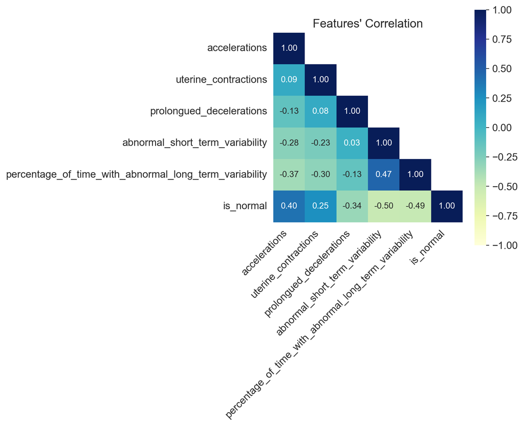

```python
display(
    plot_correlation_matrix(
        # use only training data to avoid bias in test results
        df=df_input_train[selected_feats + [target_col]], method="pearson", fig_height=5
    )
)
```

### Multicollinearity check

```python
# compute the Variance Inflation Factor (VIF) for each feature
df_vif = pd.DataFrame(
    data=[variance_inflation_factor(X_train.values, i) for i in range(len(selected_feats))],
    index=selected_feats,
    columns=["VIF"]
).sort_values("VIF", ascending=False)

df_vif
```

|  | VIF |
| --- | --- |
| percentage_of_time_with_abnormal_long_term_variability | 1.53 |
| abnormal_short_term_variability | 1.33 |
| accelerations | 1.22 |
| uterine_contractions | 1.12 |
| prolongued_decelerations | 1.07 |

## 5. Classifier Model

### Select classifier: Logistic Regression or XGBoost

```python
MODEL_SELECTION = "logistic_regression"
# MODEL_SELECTION = "xgboost"

model_selection_error = ValueError(
    "'MODEL_SELECTION' must be either 'logistic_regression' or 'xgboost'. "
    f"Got {MODEL_SELECTION} instead."
)
```

### Hyperparameter tuning with K-Fold Cross Validation

- **Logistic Regression**: In binary classification with imbalanced classes, avoid setting `class_weight="balanced"` if you want to use the model's predicted probabilities as proxies for the real probability distributions of the target classes, that is, if you want to interpret the predicted probability as "the actual probability that the sample belongs to the class". In this case, you should not use 50% as the threshold for the binary classification; you should find the optimal threshold using the ROC Curve (detailed below) to maximize the model's performance.
- **XGBoost**: For a detailed explanation of XGBoost's parameters, refer to: https://www.kaggle.com/code/prashant111/a-guide-on-xgboost-hyperparameters-tuning/notebook

```python
if MODEL_SELECTION == "logistic_regression":
    Estimator = LogisticRegression
    cv_search_space = {
        "penalty": ["l1", "l2", "elasticnet"],
        "C": np.logspace(-3, 1, num=9, base=10.0),
        "class_weight": [None],
    }
elif MODEL_SELECTION == "xgboost":
    Estimator = XGBClassifier
    cv_search_space = {
        "objective": ["binary:logistic"],
        "n_estimators": [30, 40, 50],
        "learning_rate": [0.1],
        "max_depth": [3, 4, 6],
        "min_child_weight": [2, 4],
        "gamma": [0, 0.5],
        "alpha": [0, 0.3],
        "scale_pos_weight": [1],
        "lambda": [1],
        ## "subsample": [0.8, 1.0],
        ## "colsample_bytree": [0.8, 1.0],
        "verbosity": [0],
    }
else:
    raise model_selection_error
```

For the full list of scikit-learn's scoring string names, refer to: https://scikit-learn.org/stable/modules/model_evaluation.html#string-name-scorers

```python
cv_scoring_metrics = {
    "roc_auc": "ROC AUC",
    "accuracy": "Accuracy",
    "precision": "Precision",
    "recall": "Recall",
    "f1": "F1 Score",
}
refit_metric = "f1"  # metric to optimize for the final model
```

```python
%%time
# define evaluation
kfold_cv = RepeatedStratifiedKFold(n_splits=3, n_repeats=1, random_state=RANDOM_SEED)
# define search
grid_search = GridSearchCV(
    estimator=Estimator(),
    param_grid=cv_search_space,
    scoring=list(cv_scoring_metrics.keys()),
    cv=kfold_cv,
    refit=refit_metric,
    verbose=1,
)
# execute search
result_cv = grid_search.fit(X_train, y_train)
```

```
Fitting 3 folds for each of 27 candidates, totalling 81 fits
```

```
CPU times: user 220 ms, sys: 15.6 ms, total: 236 ms
Wall time: 284 ms
```

```python
print("Grid Search CV Best Model - Scoring Metrics:")
for i, (metric_key, metric_name) in enumerate(cv_scoring_metrics.items(), start=1):
    print(
        f"  {str(i) + ".":>2} {metric_name:.<10} "
        f"{result_cv.cv_results_[f"mean_test_{metric_key}"][result_cv.best_index_]:.3f}"
    )
print(f"\nBest Hyperparameters: {result_cv.best_params_}")
```

```
Grid Search CV Best Model - Scoring Metrics:
  1. ROC AUC... 0.950
  2. Accuracy.. 0.900
  3. Precision. 0.925
  4. Recall.... 0.949
  5. F1 Score.. 0.937

Best Hyperparameters: {'C': np.float64(1.0), 'class_weight': None, 'penalty': 'l2'}
```

### Final Model

```python
# instantiate model with best hyperparameters and additional kwargs
if MODEL_SELECTION == "logistic_regression":
    model_kwargs = dict()
    model_fit_kwargs = dict()
elif MODEL_SELECTION == "xgboost":
    eval_metrics = dict(
        logloss="Binary Cross-entropy Loss (Log-loss)",
        error="Binary Classification Error Rate",
        auc="ROC AUC",
    )
    model_kwargs = dict(eval_metric=list(eval_metrics.keys()))
    model_fit_kwargs = dict(
        eval_set=[(X_train, y_train), (X_test, y_test)],
        verbose=False
    )
else:
    raise model_selection_error

model = Estimator(**result_cv.best_params_, **model_kwargs, random_state=RANDOM_SEED)
```

```python
# Fit model and make predictions
model.fit(X_train, y_train, **model_fit_kwargs)
# Make predictions ([:, 1] returns the probability of the positive class)
y_pred_proba_train = pd.Series(data=model.predict_proba(X_train)[:, 1], index=X_train.index)
y_pred_proba = pd.Series(data=model.predict_proba(X_test)[:, 1], index=X_test.index)
```

```python
if MODEL_SELECTION == "xgboost":
    display(plot_eval_metrics_xgb(model.evals_result(), eval_metrics))
```

**Plot target rate per group of predicted probability**

A good model should have increasing target rate for each group of predicted probability (e.g. quartiles, deciles)

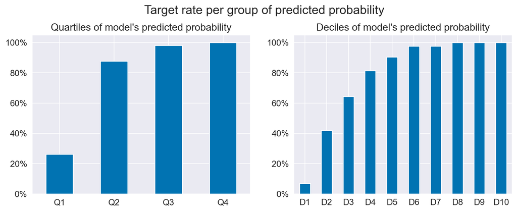

```python
display(plot_target_rate(y_test, y_pred_proba))
```

**Define optimal threshold for separating classes using the ROC Curve**

The optimal threshold is the one that maximizes the difference between the True Positive Rate (TPR) and False Positive Rate (FPR).

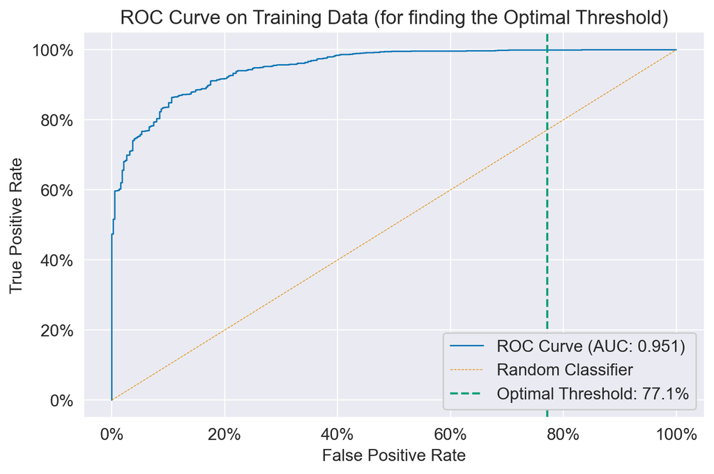

```python
# use only training data to get optimal threshold to avoid bias in test results
fig_roc_curve, optimal_thresh = plot_roc_curve(
    y_true=y_train,
    y_pred_proba=y_pred_proba_train,
    title="ROC Curve on Training Data (for finding the Optimal Threshold)",
    return_optimal_thresh=True
)
display(fig_roc_curve)
```

```python
# compute binary predictions
print(f"Optimal Threshold for Classification: {100*optimal_thresh:.2f}%")
y_pred_train = (y_pred_proba_train > optimal_thresh).astype(int)
y_pred = (y_pred_proba > optimal_thresh).astype(int)
```

```
Optimal Threshold for Classification: 77.12%
```

### Feature Importance

- For Logistic Regression: coefficients values and statistical significance
- For XGBoost: SHAP analysis and Gain Metric

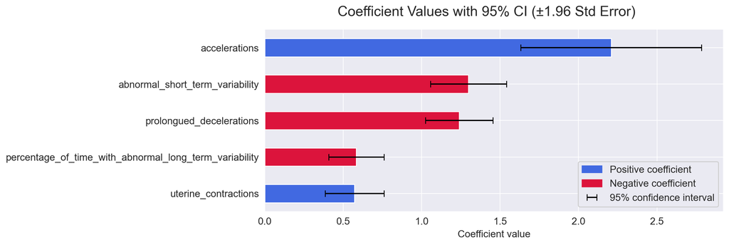

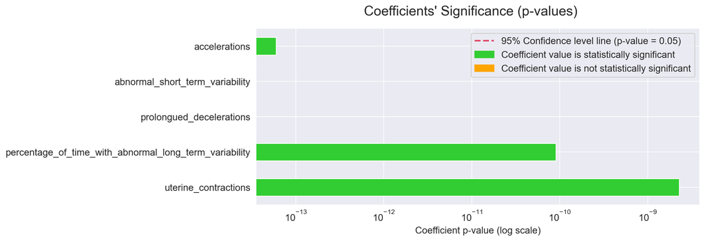

```python
if MODEL_SELECTION == "logistic_regression":
    df_coefficients = build_coefficients_table(
        coefficients=model.coef_[0],
        intercept=model.intercept_[0],
        X_train=X_train,
        y_pred_train=y_pred_proba_train,
        y_train=y_train,
        problem_type="classification",
    )
    display(
        plot_coefficients_values(df_coefficients),
        plot_coefficients_significance(
            df_coefficients,
            log_scale=bool(df_coefficients["p-values"].max() < 2e-4)
        )
    )

elif MODEL_SELECTION == "xgboost":
    # compute SHAP values
    explainer = shap.Explainer(model)
    shap_values = explainer(X_test)
    # shap plots
    display(
        plot_shap_importance(shap_values),
        plot_shap_beeswarm(shap_values),
        plot_gain_metric_xgb(model, X_test),
    )

else:
    raise model_selection_error
```

### Performance Metrics

```python
df_train_metrics = pd.Series(
    compute_binary_classification_metrics(y_train, y_pred_train, y_pred_proba_train)
).to_frame(name="Train Metrics")
df_test_metrics = pd.Series(
    compute_binary_classification_metrics(y_test, y_pred, y_pred_proba)
).to_frame(name="Test Metrics")

print("Final Model - Scoring Metrics on Train & Test Datasets:")
df_metrics = df_train_metrics.join(df_test_metrics)
display(df_metrics)
```

```
Final Model - Scoring Metrics on Train & Test Datasets:
```

|  | Train Metrics | Test Metrics |
| --- | --- | --- |
| Accuracy | 0.87 | 0.85 |
| Precision | 0.97 | 0.96 |
| Recall | 0.86 | 0.84 |
| F1 Score | 0.91 | 0.90 |
| ROC AUC | 0.95 | 0.94 |
| GINI | 0.90 | 0.88 |
| KS Gain | 0.75 | 0.71 |

#### Confusion Matrix

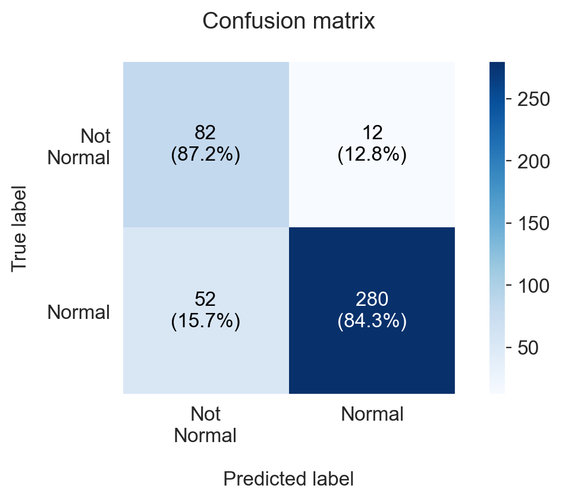

```python
# Confusion Matrix
display(
    plot_confusion_matrix(
        y_test,
        y_pred,
        estimator=model,
        target_classes_dict=target_classes_dict,
        normalize="true",
    )
)
```

#### ROC AUC

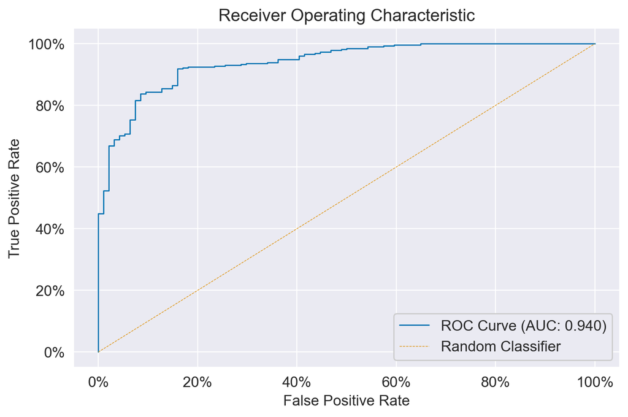

```python
display(plot_roc_curve(y_test, y_pred_proba))
```

#### KS Gain

```python
df_ks, ks_score = build_ks_table(y_test, y_pred_proba, return_ks=True)
print(f"KS score: {ks_score * 100:.2f} p.p.")
beautify_ks_table(df_ks)
```

```
KS score: 70.65 p.p.
```

|  | min score | max score | n positives | n negatives | n all | positive rate | negative rate | cum positives | cum negatives | cumpct positives | cumpct negatives | diff | KS Gain |
| --- | --- | --- | --- | --- | --- | --- | --- | --- | --- | --- | --- | --- | --- |
| 0 | 0.00 | 0.19 | 3 | 40 | 43 | 6.98% | 93.02% | 3 | 40 | 0.90% | 42.55% | 41.65 pp |  |
| 1 | 0.20 | 0.43 | 18 | 25 | 43 | 41.86% | 58.14% | 21 | 65 | 6.33% | 69.15% | 62.82 pp |  |
| 2 | 0.44 | 0.74 | 27 | 15 | 42 | 64.29% | 35.71% | 48 | 80 | 14.46% | 85.11% | 70.65 pp | <-- |
| 3 | 0.74 | 0.90 | 35 | 8 | 43 | 81.40% | 18.60% | 83 | 88 | 25.00% | 93.62% | 68.62 pp |  |
| 4 | 0.90 | 0.97 | 38 | 4 | 42 | 90.48% | 9.52% | 121 | 92 | 36.45% | 97.87% | 61.43 pp |  |
| 5 | 0.97 | 0.99 | 42 | 1 | 43 | 97.67% | 2.33% | 163 | 93 | 49.10% | 98.94% | 49.84 pp |  |
| 6 | 0.99 | 0.99 | 41 | 1 | 42 | 97.62% | 2.38% | 204 | 94 | 61.45% | 100.00% | 38.55 pp |  |
| 7 | 0.99 | 1.00 | 43 | 0 | 43 | 100.00% | 0.00% | 247 | 94 | 74.40% | 100.00% | 25.60 pp |  |
| 8 | 1.00 | 1.00 | 42 | 0 | 42 | 100.00% | 0.00% | 289 | 94 | 87.05% | 100.00% | 12.95 pp |  |
| 9 | 1.00 | 1.00 | 43 | 0 | 43 | 100.00% | 0.00% | 332 | 94 | 100.00% | 100.00% | 0.00 pp |  |

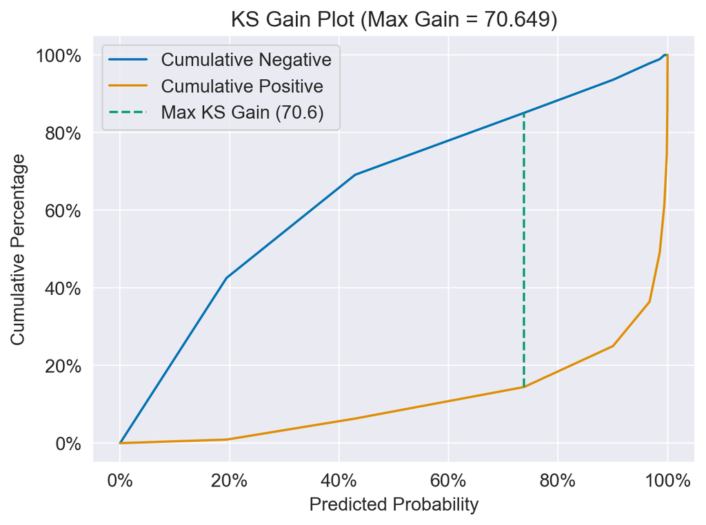

```python
display(plot_ks_table(df_ks))
```